# Quantifying metacognition with the `hmetad` package in `R`

[Kevin O’Neill](https://kevingoneill.github.io)

Department of Experimental Psychology  
University College London

# https://metacoglab.github.io/hmetad_workshop

[figure not shown]

# What is metacognition?

## Thinking about thinking

[figure not shown]

Nelson (1990)

## Hierarchies of metacognition

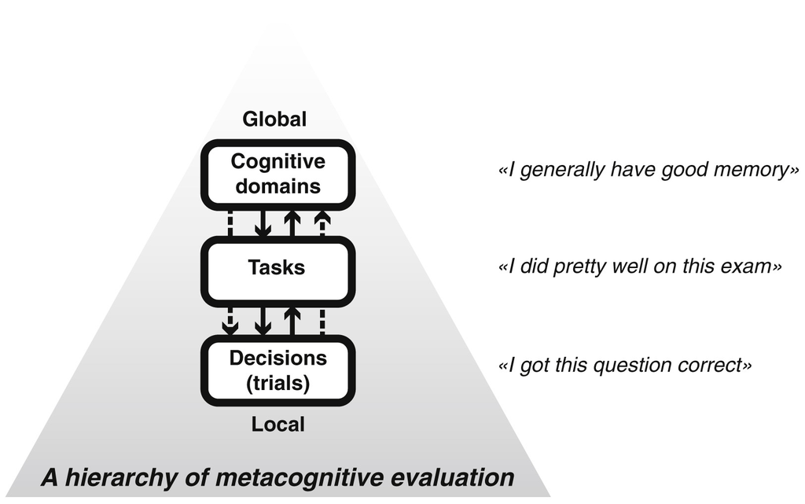

Seow et al. (2021)

## Type I and Type II decisions

[figure not shown]

## Type I and Type II decisions

### Type I

Decision about the world

- Is there a stimulus present?
- Are the dots moving left or right?
- Have I seen this image before?

### Type II

Decision about yourself

- Was my decision correct?
- How good am I at this task?
- Have I been paying attention?

Clarke et al. (1959)

## Quantifying Type I decisions

To understand how well someone performs a task, why not just calculate:

- % correct?
- correlation(stimulus, response)?

**Need to control for response bias!**

## Quantifying Type I decisions

### Sensitivity ($d'$)

How much do responses distinguish between stimuli?

### Response Bias ($c$)

Is one response more likely overall?

[figure not shown]

Green and Swets (1966)

## Quantifying Type II decisions

#### Metacognitive sensitivity

How much does distinguish between correct and incorrect decisions?

#### Metacognitive Bias

How much evidence is required to respond with high confidence?

We would like the same dissociation as for Type I decisions

But now we need to control for Type I sensitivity and bias!

Fleming and Lau (2014)

# Measures of metacognitive sensitivity

## General approach

|  | Stimulus = 0 | Stimulus = 1 |
| --- | --- | --- |
| **Response = 0** | Correct Rejection | Miss |
| **Response = 1** | False Alarm | Hit |

|  | Accuracy = 0 | Accuracy = 1 |
| --- | --- | --- |
| **Confidence = 0** | Correct Rejection 2 | Miss 2 |
| **Confidence = 1** | False Alarm 2 | Hit 2 |

Each approach determines metacognitive sensitivity using these probabilities

## Correlational approaches

```python
accuracy = [1, 0, 1, 1, 0, 1, 0, ...]
confidence = [0, 0, 1, 1, 0, 1, 0, ...]

phi = cor(accuracy, confidence)
```

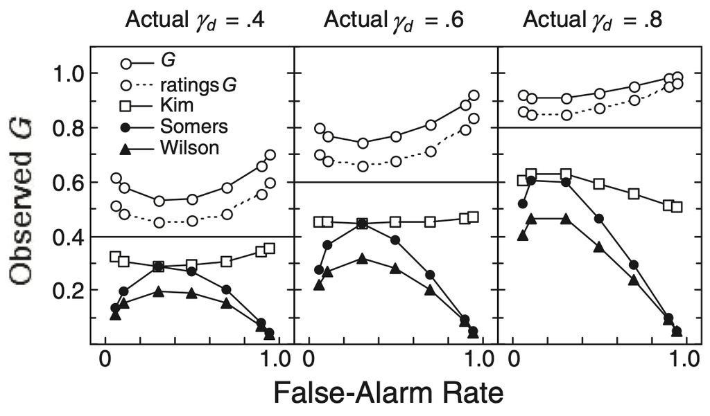

Fleming and Lau (2014); Masson and Rotello (2009)

## Should I use correlational measures?

#### Pros

- Very simple, can be used with any design
- Can establish presence (vs. absence) of metacognition

#### Cons

- Confounded by Type I performance
- Confounded by metacognitive bias
- Requires careful controls to compare between conditions

## Area under Type II ROC (AUROC2)

[figure not shown]

Clarke et al. (1959)

## Issues with AUROC2

[figure not shown]

Does not control for Type I performance!

## Should I use AUROC2?

#### Pros

- Non-parametric, can be used with any design
- Usually independent of metacognitive bias

#### Cons

- Confounded by Type I performance
- Confounded by Type I response bias
- Requires controlling for performance (experimentally or statistically)

## meta-$d'$

[figure not shown]

## The meta-$d'$ model

[figure not shown]

If we make assumptions about the distribution of evidence,  
we can *model* the Type II ROC!

## Taxonomy of metacognitive measures

- **Metacognitive sensitivity**: how much information one has about the stimulus when making confidence ratings (i.e., $\textrm{meta-}d'$)
- **Metacognitive efficiency**: metacognitive capacity, relative to Type I performance (i.e., $M = \frac{\textrm{meta-}d'}{d'}$)
- **Metacognitive bias**: overall level of confidence (i.e., $\textrm{meta-}\Delta$, based on $\textrm{meta-}c_2$)

## Model-fitting approach

**Bayesian inference**

Determine the model parameters (e.g., $\textrm{meta-}d'$, $\textrm{meta-}c_2$) are most likely given the participant’s observed Type I and Type II responses

$$\begin{align*}
p(\theta \;\vert\; \mathcal{D}) \propto p(\mathcal{D} \;\vert\; \theta) p(\theta)
\end{align*}$$

Posterior Likelihood Prior

In the `hmetad` package, we approximate this calculation using the probabilistic programming language Stan

Fleming (2017)

## Should I use meta-$d'$/$M$-ratio?

#### Pros

- Provides principled metric for metacognitive sensitivity
- Takes into account both Type I and Type II response biases
- Easy to control for performance (e.g. using $M = \frac{\textrm{meta-}d'}{d'}$)
- Allows hierarchical modeling of participants/stimuli

#### Cons

- Currently only developed for 2-choice discrimination tasks
- Equal-variance Gaussian assumptions may not hold for some tasks
- Claims of invariance to Type I criterion and Type II bias have been questioned (Rausch et al. 2023; Xue et al. 2021)

## Alternative approaches

There are a wide range of other kinds of models of confidence:

- Bayesian models (Fleming and Daw 2017; Mamassian and Gardelle 2025; Boundy-Singer et al. 2023; Kozyra et al. 2026)
- Temporally dynamic models (Maniscalco et al. 2021; Desender et al. 2022; Hellmann et al. 2024)
- Post-decisional models (Navajas et al. 2016; Hellmann et al. 2024)
- Models of global metacognition (Katyal et al. 2025; Rouault et al. 2019)

Helpful reviews (Rausch et al. 2023; Rahnev 2025)

## Entry points into the literature

- Fleming (2024)
- Mamassian (2016)
- Rahnev et al. (2022)
- Rahnev (2021)
- Peters (2022)

# Over to you!

Open https://metacoglab.github.io/hmetad_workshop in your browser and follow along the instructions.

If you can’t get it installed/running, let me know! Otherwise, you can look at the pre-generated outputs.

[figure not shown]

# Bonus slides

## The meta-$d'$ model

[figure not shown]

$$\begin{align*}
\mathbf{y}_s &\sim \text{Multinomial}(\pi_s) \\
\pi_s &= \textrm{metad_pmf}_s(d', c, \textrm{meta-}d', \textrm{meta-}c, \mathbf{\textbf{meta-}c_{2}^0}, \mathbf{\textbf{meta-}c_{2}^{1}}) \\
\textrm{meta-}d' &= \textrm{exp}(\textrm{log-}M) \; d' \\
\textrm{meta-}c &= \begin{cases}
c & \textrm{ABSOLUTE} \\
\textrm{exp}(\textrm{log-}M) \; c & \textrm{RELATIVE} \\
\end{cases} \\
\mathbf{\textbf{meta-}c_{2}^0} &= \textrm{meta-}c - \text{cumulative_sum}(\text{exp}(\mathbf{\textbf{log-dmeta-}c_2^0})) \\
\mathbf{\textbf{meta-}c_{2}^1} &= \textrm{meta-}c + \text{cumulative_sum}(\text{exp}(\mathbf{\textbf{log-dmeta-}c_2^1}))
\end{align*}$$

## Advantages of hierarchical Bayesian modeling

- Point estimates of meta-$d'$ are noisy; frequentist estimates of hit/false alarm rates fail to account for uncertainty
- Optimally combines information about within-participant and between-participant variability
- Avoids padding (edge-correction) for zero-count cells
- Straightforward testing of group-level and participant-level hypotheses
- Can also model stimulus variability (i.e., crossed random effects)

## Advantages of hierarchical Bayesian modeling

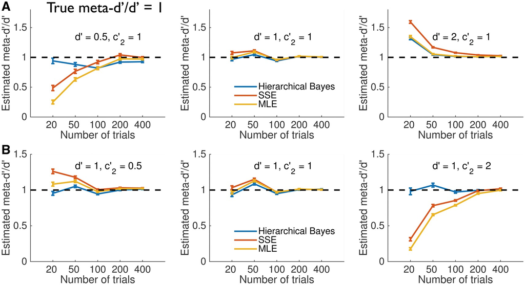

Fleming (2017)

## Differences between `hmetad` and the Hmeta-d toolbox

### `hmetad`

- implemented in [Stan](https://mc-stan.org/)
- $d'$ and $c$ modeled
- meta-$c_2$ modeled using ordered transform
- uses `R` formula syntax for arbitrary model specifications

### Hmeta-d toolbox

- implemented in [JAGS](https://mcmc-jags.sourceforge.io/)
- $d'$ and $c$ point estimates taken as data
- meta-$c_2$ modeled on identity scale
- has separate files for common model specifications

## References

Boundy-Singer, Zoe M, Corey M Ziemba, and Robbe LT Goris. 2023. “Confidence Reflects a Noisy Decision Reliability Estimate.” *Nature Human Behaviour* 7 (1): 142–54.

Clarke, Frank R, Theodore G Birdsall, and Wilson P Tanner Jr. 1959. “Two Types of ROC Curves and Definitions of Parameters.” *The Journal of the Acoustical Society of America* 31 (5): 629–30.

Desender, Kobe, Luc Vermeylen, and Tom Verguts. 2022. “Dynamic Influences on Static Measures of Metacognition.” *Nature Communications* 13 (1): 4208.

Fleming, Stephen M. 2017. “HMeta-d: Hierarchical Bayesian Estimation of Metacognitive Efficiency from Confidence Ratings.” *Neuroscience of Consciousness* 2017 (1): nix007.

Fleming, Stephen M. 2024. “Metacognition and Confidence: A Review and Synthesis.” *Annual Review of Psychology* 75 (1): 241–68.

Fleming, Stephen M, and Nathaniel D Daw. 2017. “Self-Evaluation of Decision-Making: A General Bayesian Framework for Metacognitive Computation.” *Psychological Review* 124 (1): 91.

Fleming, Stephen M, and Hakwan C Lau. 2014. “How to Measure Metacognition.” *Frontiers in Human Neuroscience* 8: 443.

Green, David Marvin., and John A. Swets. 1966. *Signal Detection Theory and Psychophysics*. Wiley.

Hellmann, Sebastian, Michael Zehetleitner, and Manuel Rausch. 2024. “Confidence Is Influenced by Evidence Accumulation Time in Dynamical Decision Models.” *Computational Brain & Behavior* 7 (3): 287–313.

Katyal, Sucharit, Quentin JM Huys, Raymond J Dolan, and Stephen M Fleming. 2025. “Distorted Learning from Local Metacognition Supports Transdiagnostic Underconfidence.” *Nature Communications* 16 (1): 1854.

Kozyra, Wiktoria, Kevin O’Neill, and Stephen M. Fleming. 2026. “Confidence Is Detection-Like in High-Dimensional Spaces.” *Open Mind*.

Mamassian, Pascal. 2016. “Visual Confidence.” *Annual Review of Vision Science* 2 (1): 459–81.

Mamassian, Pascal, and Vincent de Gardelle. 2025. “The Confidence-Noise Confidence-Boost (CNCB) Model of Confidence Rating Data.” *PLOS Computational Biology* 21 (4): e1012451.

Maniscalco, Brian, Brian Odegaard, Piercesare Grimaldi, et al. 2021. “Tuned Inhibition in Perceptual Decision-Making Circuits Can Explain Seemingly Suboptimal Confidence Behavior.” *PLoS Computational Biology* 17 (3): e1008779.

Masson, Michael EJ, and Caren M Rotello. 2009. “Sources of Bias in the Goodman–Kruskal Gamma Coefficient Measure of Association: Implications for Studies of Metacognitive Processes.” *Journal of Experimental Psychology: Learning, Memory, and Cognition* 35 (2): 509.

Navajas, Joaquin, Bahador Bahrami, and Peter E Latham. 2016. “Post-Decisional Accounts of Biases in Confidence.” *Current Opinion in Behavioral Sciences* 11: 55–60.

Nelson, Thomas O. 1990. *Metamemory: A Theoretical Framework and New Findings*. Edited by Gordon H. Bower. Vol. 26. Psychology of Learning and Motivation. Academic Press. https://doi.org/10.1016/S0079-7421(08)60053-5.

Peters, Megan AK. 2022. “Towards Characterizing the Canonical Computations Generating Phenomenal Experience.” *Neuroscience & Biobehavioral Reviews* 142: 104903.

Rahnev, Dobromir. 2021. “Visual Metacognition: Measures, Models, and Neural Correlates.” *American Psychologist* 76 (9): 1445.

Rahnev, Dobromir. 2025. “A Comprehensive Assessment of Current Methods for Measuring Metacognition.” *Nature Communications* 16 (1): 701.

Rahnev, Dobromir, Tarryn Balsdon, Lucie Charles, et al. 2022. “Consensus Goals in the Field of Visual Metacognition.” *Perspectives on Psychological Science* 17 (6): 1746–65.

Rausch, Manuel, Sebastian Hellmann, and Michael Zehetleitner. 2023. “Measures of Metacognitive Efficiency Across Cognitive Models of Decision Confidence.” *Psychological Methods*.

Rouault, Marion, Peter Dayan, and Stephen M Fleming. 2019. “Forming Global Estimates of Self-Performance from Local Confidence.” *Nature Communications* 10 (1): 1141.

Seow, Tricia XF, Marion Rouault, Claire M Gillan, and Stephen M Fleming. 2021. “How Local and Global Metacognition Shape Mental Health.” *Biological Psychiatry* 90 (7): 436–46.

Xue, Kai, Medha Shekhar, and Dobromir Rahnev. 2021. “Examining the Robustness of the Relationship Between Metacognitive Efficiency and Metacognitive Bias.” *Consciousness and Cognition* 95: 103196.